# FinalTakeHome_Jie He

Part A: Ozone Data

```r
# data preparation
library(mlbench)
library(plyr)
data(Ozone)
#summary(Ozone)
mydf <- data.frame(Ozone)
mydf1 <- mydf[,-c(2,3)]
mydf2 <- rename(mydf1, c("V1"="month", "V4"="dailymax", "V5"="pressure", "V6"="windlax", "V7"="humlax", "V8"="tsand", "V9"="telmonte", "V10"="invlax", "V11"="pressgrad", "V12"="invbasetemplax", "V13"="vislax"))
```

# A.1

```r
# make new data sets
mydf3 <- mydf2[complete.cases(mydf2),]
mydf4 <- mydf2[complete.cases(mydf2[,2]),]
mydf5 <- mydf2[!complete.cases(mydf2),]
# chi-squared test
library(spgs)
chisq.unif.test(as.numeric(mydf5$month), bins=12, interval=c(1,12))
```

```
##
##  Discrete uniform(1,12) chi-squared test
##
## data:  as.numeric(mydf5$month)
## X-squared = 9.638, df = 11, a = 1, b = 12, p-value = 0.5632
```

```r
month12 <- c(14,12,10,9,21,13,18,16,14,13,13,10)
chisq.test(month12)
```

```
##
##  Chi-squared test for given probabilities
##
## data:  month12
## X-squared = 9.638, df = 11, p-value = 0.5632
```

I used chi-squared test on month. The Null Hypothesis is that the data is uniformly distributed over all twelve months and the Alternate Hypothesis is that the data is not uniformly distributed over all twelve months. From the results above, X-squared = 9.638, df = 11, p-value = 0.5632. We can thus accept the null hypothesis.

# A.2

```r
library(tree)
# create trees and plots
tree1 <- tree(dailymax ~ . - month, data = mydf3)
summary(tree1)
```

```
##
## Regression tree:
## tree(formula = dailymax ~ . - month, data = mydf3)
## Variables actually used in tree construction:
## [1] "telmonte"       "tsand"          "invlax"         "pressgrad"
## [5] "invbasetemplax" "vislax"
## Number of terminal nodes:  11
## Residual mean deviance:  13.73 = 2636 / 192
## Distribution of residuals:
##    Min. 1st Qu.  Median    Mean 3rd Qu.    Max.
## -8.8670 -2.2990 -0.4808  0.0000  1.8890 12.7800
```

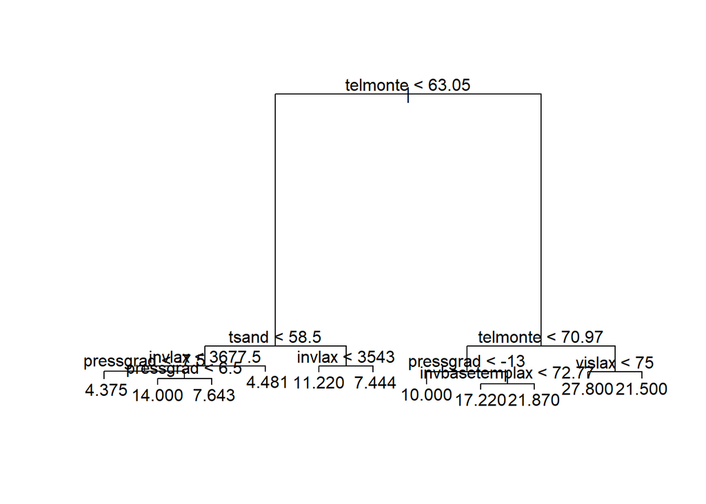

```r
plot(tree1)
text(tree1, pretty = 0)
```

```r
tree2 <- tree(dailymax ~ . - month, data = mydf4)
summary(tree2)
```

```
##
## Regression tree:
## tree(formula = dailymax ~ . - month, data = mydf4)
## Variables actually used in tree construction:
## [1] "telmonte"       "tsand"          "invlax"         "pressgrad"
## [5] "invbasetemplax" "vislax"
## Number of terminal nodes:  11
## Residual mean deviance:  13.73 = 2636 / 192
## Distribution of residuals:
##    Min. 1st Qu.  Median    Mean 3rd Qu.    Max.
## -8.8670 -2.2990 -0.4808  0.0000  1.8890 12.7800
```

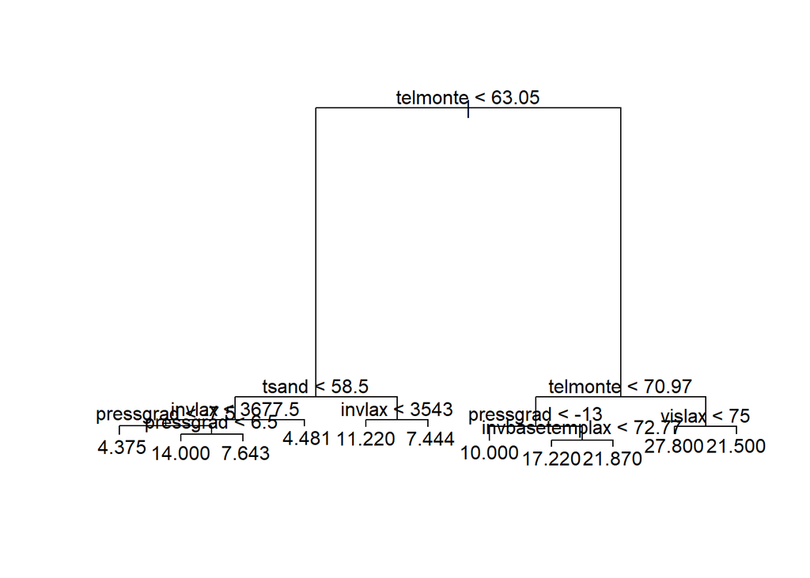

```r
plot(tree2)
text(tree2, pretty = 0)
```

From the results above, we can see that the two trees are the same.

# A.3

```r
# compute the mean of dailymax in a certain month
for(i in 1:12){
  mon <- mydf4[as.numeric(mydf4$month) == i,]
  cat("Month", i, " ")
  print(mean(mon$dailymax))
}
```

```
## Month 1  [1] 5.451613
## Month 2  [1] 7.137931
## Month 3  [1] 8.83871
## Month 4  [1] 10
## Month 5  [1] 15.76667
## Month 6  [1] 17.13333
## Month 7  [1] 20.2069
## Month 8  [1] 17.54839
## Month 9  [1] 12.35714
## Month 10  [1] 12.64516
## Month 11  [1] 7.666667
## Month 12  [1] 4.064516
```

```r
# create an aggregated dataframe
aggmons <- aggregate(mydf4$dailymax, list(mydf4$month), mean)
colnames(aggmons)[1] <- "month"
colnames(aggmons)[2] <- "dailymax_mean"
mydf6 <- merge(aggmons, mydf4, "month")
# create a linear model
fitlinear <- glm(dailymax ~ month, data = mydf4) # this linear model is implicitly calculating the mean per each month
summary(fitlinear)
```

```
##
## Call:
## glm(formula = dailymax ~ month, data = mydf4)
##
## Deviance Residuals:
##      Min        1Q    Median        3Q       Max
## -15.5484   -3.8387   -0.6667    3.1613   20.4516
##
## Coefficients:
##             Estimate Std. Error t value Pr(>|t|)
## (Intercept)    5.452      1.119   4.873 1.67e-06 ***
## month2         1.686      1.609   1.048  0.29536
## month3         3.387      1.582   2.141  0.03297 *
## month4         4.548      1.595   2.851  0.00461 **
## month5        10.315      1.595   6.467 3.38e-10 ***
## month6        11.682      1.595   7.323 1.69e-12 ***
## month7        14.755      1.609   9.170  < 2e-16 ***
## month8        12.097      1.582   7.646 2.02e-13 ***
## month9         6.906      1.624   4.253 2.72e-05 ***
## month10        7.194      1.582   4.547 7.51e-06 ***
## month11        2.215      1.595   1.389  0.16583
## month12       -1.387      1.582  -0.877  0.38120
## ---
## Signif. codes:  0 '***' 0.001 '**' 0.01 '*' 0.05 '.' 0.1 ' ' 1
##
## (Dispersion parameter for gaussian family taken to be 38.7927)
##
##     Null deviance: 22558  on 360  degrees of freedom
## Residual deviance: 13539  on 349  degrees of freedom
## AIC: 2358.9
##
## Number of Fisher Scoring iterations: 2
```

```r
# use 10-fold CV
library(boot)
set.seed(1)
cverror <- cv.glm(mydf4, fitlinear, K=10)
cverror$delta[1]
```

```
## [1] 40.04994
```

```r
rmserr <- sqrt(cverror$delta[1])
rmserr
```

```
## [1] 6.328502
```

# A.4

```r
# fit a linear model
fit.lm <- glm(dailymax ~ . - month, data = mydf3)
summary(fit.lm)
```

```
##
## Call:
## glm(formula = dailymax ~ . - month, data = mydf3)
##
## Deviance Residuals:
##      Min        1Q    Median        3Q       Max
## -11.2055   -2.7232   -0.2741    3.0891   13.3442
##
## Coefficients:
##                  Estimate Std. Error t value Pr(>|t|)
## (Intercept)    59.9517553 38.3286940   1.564 0.119421
## pressure       -0.0139111  0.0072511  -1.918 0.056527 .
## windlax         0.0276862  0.1741433   0.159 0.873847
## humlax          0.0808740  0.0237694   3.402 0.000812 ***
## tsand           0.1503404  0.0692994   2.169 0.031272 *
## telmonte        0.5253439  0.1247136   4.212 3.87e-05 ***
## invlax         -0.0010052  0.0003944  -2.549 0.011586 *
## pressgrad       0.0049796  0.0147772   0.337 0.736501
## invbasetemplax -0.1543882  0.1192917  -1.294 0.197140
## vislax         -0.0033951  0.0048963  -0.693 0.488883
## ---
## Signif. codes:  0 '***' 0.001 '**' 0.01 '*' 0.05 '.' 0.1 ' ' 1
##
## (Dispersion parameter for gaussian family taken to be 20.08543)
##
##     Null deviance: 13549.5  on 202  degrees of freedom
## Residual deviance:  3876.5  on 193  degrees of freedom
## AIC: 1196.8
##
## Number of Fisher Scoring iterations: 2
```

```r
# perform CV
library(boot)
set.seed(1)
cv.error <- cv.glm(mydf3, fit.lm, K=10)
cv.error$delta[1]
```

```
## [1] 20.7315
```

```r
rms_err <- sqrt(cv.error$delta[1])
rms_err
```

```
## [1] 4.553186
```

From the summary table above, we can see that “humlax”, “tsand”, “telmonte”, and “invlax” are significant variables based on their p-values. Notice that the MSE is 20.7315, and thus the RMSE is 4.553186.

# A.5

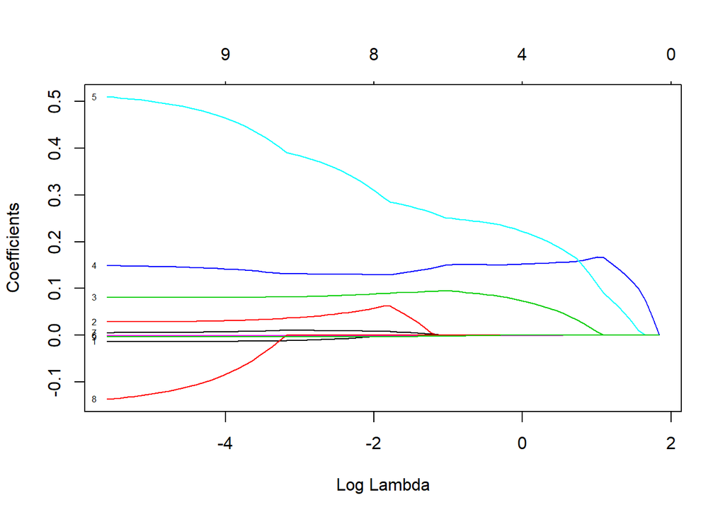

```r
# use the LASSO for the linear model
# with standardization
library(glmnet)
library(plotmo)
x <- model.matrix(dailymax ~ . - month, data = mydf3)[,-1]
y <- mydf3$dailymax
lassofit <- glmnet(x, y, alpha = 1, standardize = TRUE)
plot(lassofit, xvar = "lambda", label = TRUE)
```

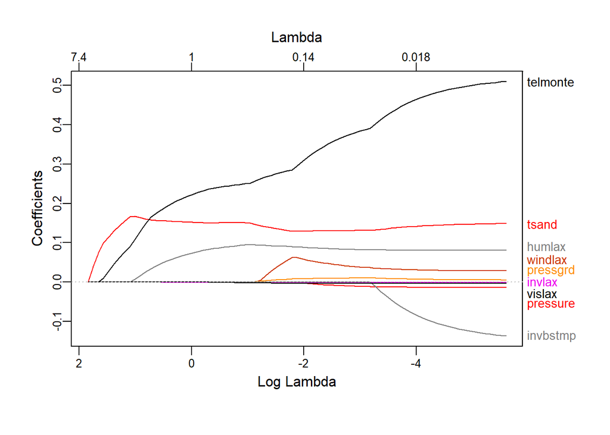

```r
plot_glmnet(lassofit)
```

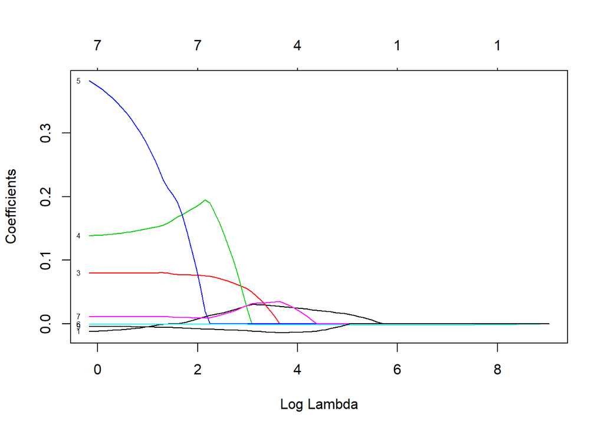

```r
# without standardization
lassofit_1 <- glmnet(x, y, alpha = 1, standardize = FALSE)
plot(lassofit_1, xvar = "lambda", label = TRUE)
```

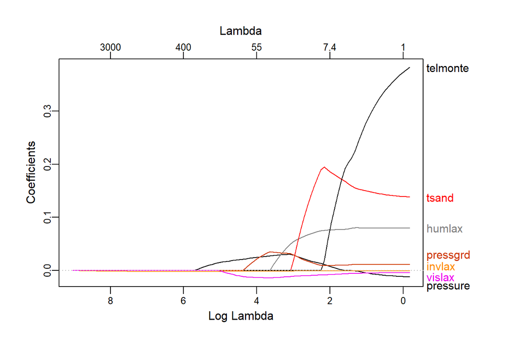

```r
plot_glmnet(lassofit_1)
```

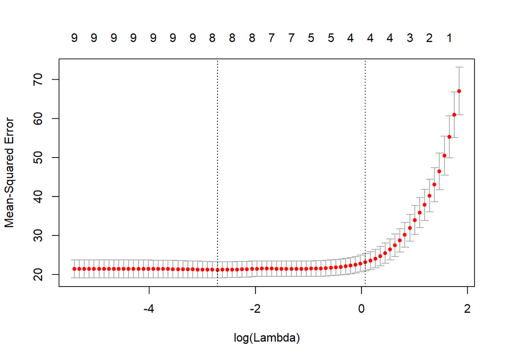

```r
# select the best lambda
set.seed(1)
cv.out <- cv.glmnet(x, y, alpha = 1)
plot(cv.out)
```

```r
bestlambda <- cv.out$lambda.min
print(bestlambda)
```

```
## [1] 0.06611466
```

From the graphs above, we can see that for the LASSO with standardization, the last five variables that leave the model as lambda increases are tsand, telmonte, humlax, invlax, and vislax; for the LASSO without standardization, the last five variables that leave the model as lambda increases are vislax, pressgrd, pressure, invlax, and humlax.

# A.6

From the results of A.2, we can see that variables actually used in tree construction are telmonte, tsand, invlax, pressgrad, invbasetemplax, and vislax. From the results of A.4, we can see that humlax, tsand, telmonte, and invlax are statistically significant based on their p-values. The results of A.5 are just showed above. We notice the following: telmonte, tsand, and invlax appear 3 times; pressgrad, vislax, and humlax appear 2 times; invbasetemplax and pressure appear only once.

Part B: Artificial Data

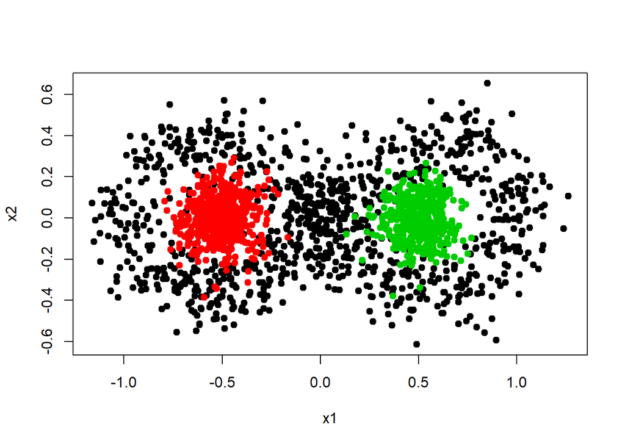

```r
make.eight = function(N, spread = .1, makeplot = T){
  # Make N points:  N/2 points in horizontal figure 8
  # N/4 points each inside the holes of the figure 8
  # spread = noise parameter
  # return data frame with coordinates x, y for each point
  # Classification variables in the data frame:
  #    charlabel =   eight   or   left   or  right
  #    label = 0 (for points on the figure 8) or = 1 (for points inside the holes)
  # plot with marked points if makeplot = T
  circ0 = runif(N/2)*2*pi
  circ = matrix(c(cos(circ0)/(1 + sin(circ0)^2),rep(-.5,N/4),rep(.5,N/4),
        cos(circ0)*sin(circ0)/(1 + sin(circ0)^2),rep(0,N/2)),ncol = 2)
  x = circ + spread*matrix(rnorm(2*N),N,2)
  y=rep(c(0,1),c(N/2,N/2))
  if(makeplot){plot(x,col = c(rep(1,N/2),rep(2,N/4),rep(3,N/4)),pch=19,
        xlab = "x1", ylab = "x2")}
  A = data.frame(x = x[,1], y = x[,2], label = as.factor(y),
        charlabel = c(rep("eight",N/2),rep("left",N/4), rep("right",N/4)))
  return(A)
}

# use the function above to create training and testing data sets
set.seed(2019)
train <- make.eight(2000, spread = .1, makeplot = T)
```

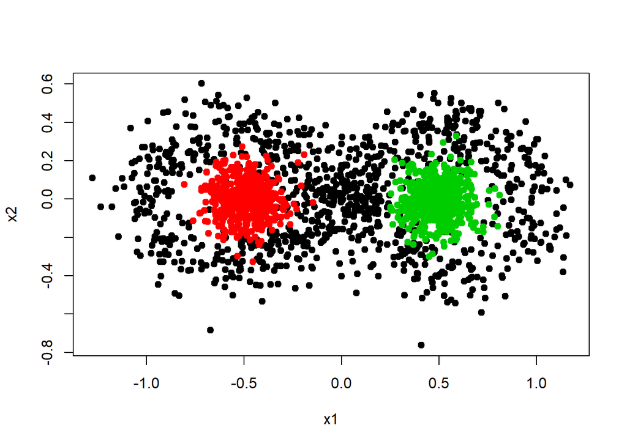

```r
test <- make.eight(2000, spread = .1, makeplot = T)
```

# B.1

# a

```r
# build a classification tree model on the training set
library(tree)
treefit <- tree(label ~ x + y, data = train)
summary(treefit)
```

```
##
## Classification tree:
## tree(formula = label ~ x + y, data = train)
## Number of terminal nodes:  10
## Residual mean deviance:  0.3766 = 749.5 / 1990
## Misclassification error rate: 0.062 = 124 / 2000
```

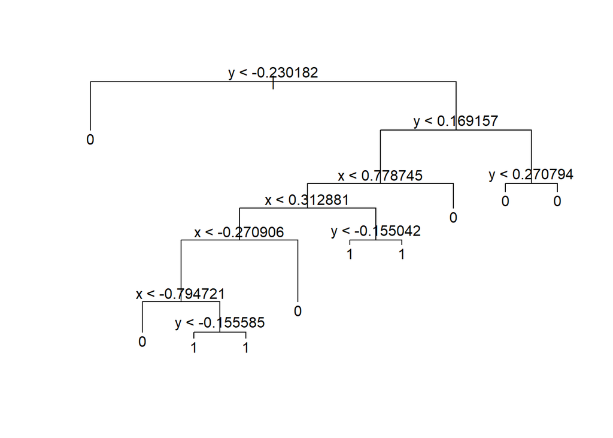

```r
plot(treefit)
text(treefit, pretty = 0)
```

```r
# training and test errors
treepred <- predict(treefit, train, type = "class")
table(treepred, train$label)
```

```
##
## treepred   0   1
##        0 936  60
##        1  64 940
```

```r
treepred_1 <- predict(treefit, test, type = "class")
table(treepred_1, test$label)
```

```
##
## treepred_1   0   1
##          0 912  72
##          1  88 928
```

From the confusion matrices above, we can see that the training error is 0.062 and the test error is 0.08.

# b

```r
# build a pruned tree
# find the best tree size
# cv method
#cv.obj <- cv.tree(treefit, FUN = prune.misclass)
#cv.obj
#plot(cv.obj$size, cv.obj$dev, type = 'b')
# the validation set approach
library(caret)
for(i in 2:10){
  prune.search <- prune.misclass(treefit, best = i)
  prune.search.pred <- predict(prune.search, test, type = "class")
  print(confusionMatrix(prune.search.pred, test$label))
}
```

```
## Confusion Matrix and Statistics
##
##           Reference
## Prediction   0   1
##          0 214   7
##          1 786 993
##
##                Accuracy : 0.6035
##                  95% CI : (0.5817, 0.625)
##     No Information Rate : 0.5
##     P-Value [Acc > NIR] : < 2.2e-16
##
##                   Kappa : 0.207
##  Mcnemar's Test P-Value : < 2.2e-16
##
##             Sensitivity : 0.2140
##             Specificity : 0.9930
##          Pos Pred Value : 0.9683
##          Neg Pred Value : 0.5582
##              Prevalence : 0.5000
##          Detection Rate : 0.1070
##    Detection Prevalence : 0.1105
##       Balanced Accuracy : 0.6035
##
##        'Positive' Class : 0
##
## Confusion Matrix and Statistics
##
##           Reference
## Prediction   0   1
##          0 549  43
##          1 451 957
##
##                Accuracy : 0.753
##                  95% CI : (0.7335, 0.7718)
##     No Information Rate : 0.5
##     P-Value [Acc > NIR] : < 2.2e-16
##
##                   Kappa : 0.506
##  Mcnemar's Test P-Value : < 2.2e-16
```

[output cut: 179 more lines]

```
##
##                   Kappa : 0.84
##  Mcnemar's Test P-Value : 0.2357
##
##             Sensitivity : 0.9120
##             Specificity : 0.9280
##          Pos Pred Value : 0.9268
##          Neg Pred Value : 0.9134
##              Prevalence : 0.5000
##          Detection Rate : 0.4560
##    Detection Prevalence : 0.4920
##       Balanced Accuracy : 0.9200
##
##        'Positive' Class : 0
##
```

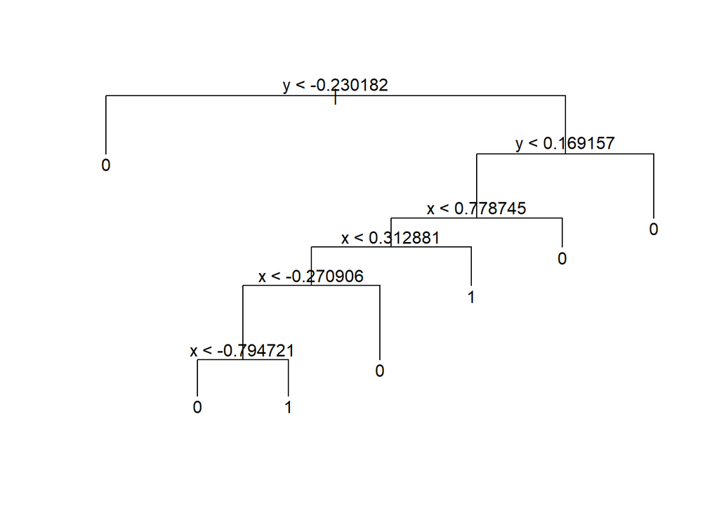

```r
# the best pruned tree
prune.obj <- prune.misclass(treefit, best = 7)
plot(prune.obj)
text(prune.obj, pretty = 0)
```

```r
# training and test errors for both pruned and unpruned trees
summary(prune.obj)
```

```
##
## Classification tree:
## snip.tree(tree = treefit, nodes = c(7L, 25L, 97L))
## Number of terminal nodes:  7
## Residual mean deviance:  0.4472 = 891.2 / 1993
## Misclassification error rate: 0.062 = 124 / 2000
```

```r
prunepred_1 <- predict(prune.obj, train, type = "class")
table(prunepred_1, train$label)
```

```
##
## prunepred_1   0   1
##           0 936  60
##           1  64 940
```

```r
prunepred <- predict(prune.obj, test, type = "class")
table(prunepred, test$label)
```

```
##
## prunepred   0   1
##         0 912  72
##         1  88 928
```

We can use the validation set approach to obtain the test error rates for a bunch of pruned trees and simply choose the smallest number of terminal nodes with the lowest test error rate. From the confusion matrices generated from 7-node pruned tree above, we can see that they are the same as the ones in part a. That means the pruned tree gives the same predictions for the training and test data.

# c

```r
# cv comparison
cv.obj <- cv.tree(treefit, FUN = prune.misclass)
cv.obj
```

```
## $size
## [1] 10  7  6  3  2  1
##
## $dev
## [1]  133  133  186  446 1062 1062
##
## $k
## [1] -Inf    0   55   97  262  268
##
## $method
## [1] "misclass"
##
## attr(,"class")
## [1] "prune"         "tree.sequence"
```

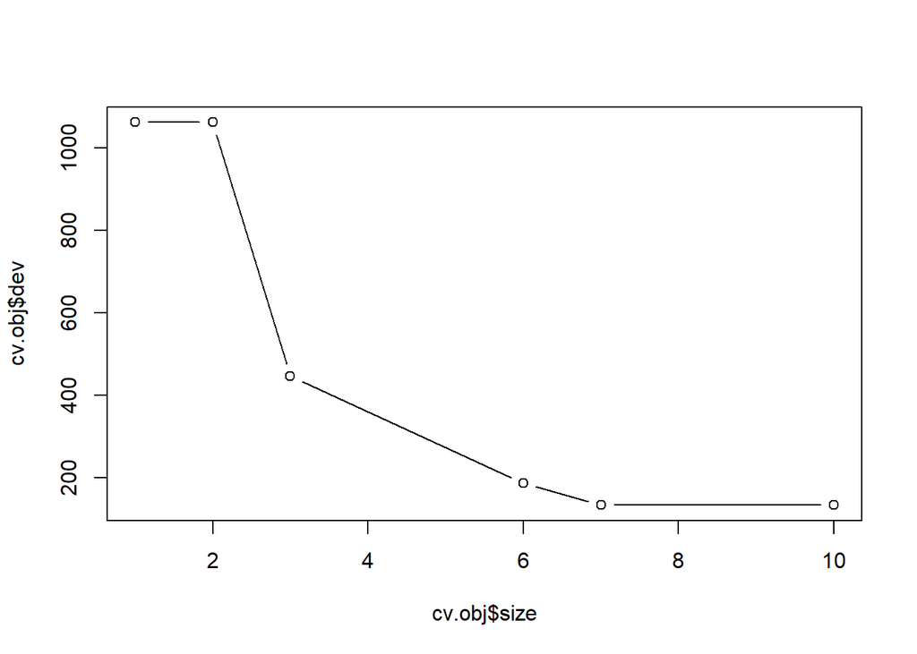

```r
plot(cv.obj$size, cv.obj$dev, type = 'b')
```

Let’s assume that we have 2000 obs and we want to build a decision tree to predict 0/1. First Split: var1 splits 2000 into 1400 1s, 600 0s; Second Split: var2 splits the above 1400 into 900 1s, 500 0s; Third Split: var3 splits the above 900 into 700 1s, 200 0s, and so on. we might obtain all 1s or all 0s at the seventh split. If the number of terminal nodes used for the pruned tree is too small (less than six in our problem), the pruned tree will be too simple and stop growing after the first few splits. It cannot catch all 1s or 0s at the end and thus it yields poor predictive performance. Both CV and the validation set approach (from part b) results show us that pruning a tree for data such as these in this problem to fewer than six nodes will most likely result in substantially worse performance.

# B.2

# a

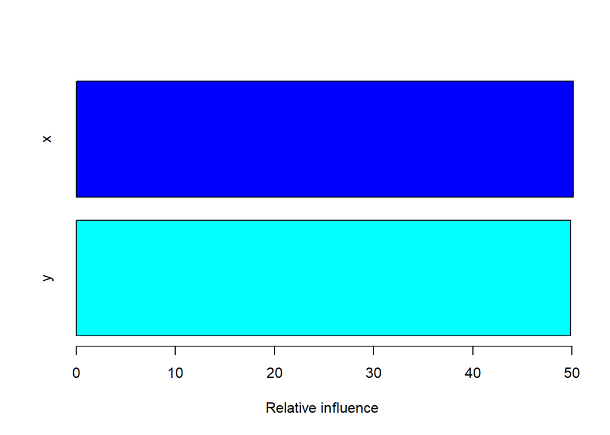

```
##   var  rel.inf
## x   x 50.12866
## y   y 49.87134
```

```r
# fit a boosted tree model with interaction depth < 3
library(gbm)
set.seed(2019)
# data type transformation
train_1 <- transform(train, label = as.numeric(label))
train_2 <- transform(train_1, label = label - 1)
test_1 <- transform(test, label = as.numeric(label))
test_2 <- transform(test_1, label = label - 1)
# notice that the value of the shrinkage parameter is set to 0.02 and thus ntrees * shrinkage = 5000 * 0.02 = 100 < 200
boostfit <- gbm(label ~ x + y, data = train_2, distribution = "bernoulli", n.trees = 5000, interaction.depth = 2, shrinkage = 0.02)
summary(boostfit)
```

```r
# use the boosted model on both training and test sets
boostpred <- predict(boostfit, newdata = train_2, n.trees = 5000, type = "response")
boost.pred <- ifelse(boostpred > 0.5, 1, 0) # cutoff = 0.5
table(boost.pred, train_2$label)
```

```
##
## boost.pred   0   1
##          0 973  22
##          1  27 978
```

```r
boostpred_1 <- predict(boostfit, newdata = test_2, n.trees = 5000, type = "response")
boost.pred_1 <- ifelse(boostpred_1 > 0.5, 1, 0) # cutoff = 0.5
table(boost.pred_1, test_2$label)
```

```
##
## boost.pred_1   0   1
##            0 910  54
##            1  90 946
```

From the confusion matrices above, we can see that the training error rate is 0.0245 and the test error rate is 0.072. It means that the model is unable to fit the training data very well. interaction.depth parameter refers to the number of splits which gbm has to perform on a tree (starting from a single node). It is equal to the number of the maximum nodes per tree. In this case, 2 is not good enough because the resulting tree with 2 nodes is not deep enough to capture every single element with correct label. Since the test error rate is high compared with the training error rate, it seems that the model still overfits the training data.

# b

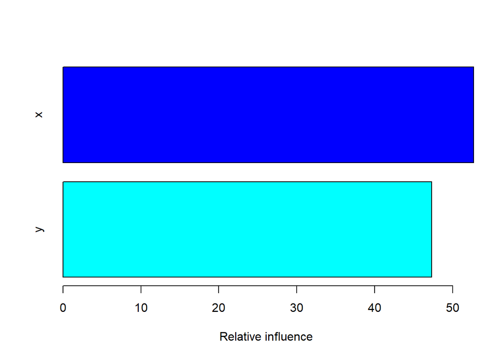

```
##   var  rel.inf
## x   x 52.69393
## y   y 47.30607
```

```r
# fit a boosted tree model with sufficiently large interaction depth
# notice that the value of the shrinkage parameter is set to 0.02 and thus ntrees * shrinkage = 5000 * 0.02 = 100 < 200
set.seed(2019)
boostfit_1 <- gbm(label ~ x + y, data = train_2, distribution = "bernoulli", n.trees = 5000, interaction.depth = 4, shrinkage = 0.02)
summary(boostfit_1)
```

```r
# use the boosted model on both training and test sets
boostpred_2 <- predict(boostfit_1, newdata = train_2, n.trees = 5000, type = "response")
boost.pred_2 <- ifelse(boostpred_2 > 0.5, 1, 0) # cutoff = 0.5
table(boost.pred_2, train_2$label)
```

```
##
## boost.pred_2    0    1
##            0  997    0
##            1    3 1000
```

```r
#boostpred_3 <- predict(boostfit_1, newdata = test_2, n.trees = 5000, type = "response")
#boost.pred_3 <- ifelse(boostpred_3 > 0.5, 1, 0) # cutoff = 0.5
#table(boost.pred_3, test_2$label)
```

# B.3

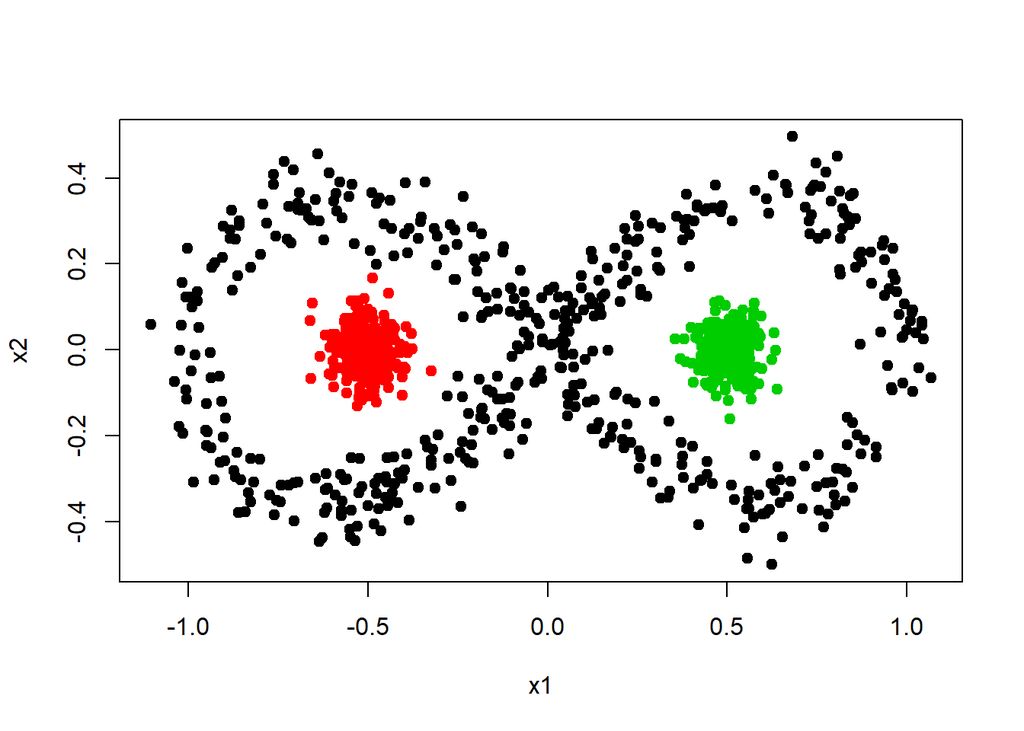

```r
# generate new data set and do data cleaning
set.seed(2019)
newdata <- make.eight(1000, spread = 0.05, makeplot = T)
```

```r
newdata$label <- NULL
```

In this problem, I choose “Make a scatterplot of the datapoints colored by cluster label”. This is a simple but efficient way to evaluate the results. The plot generated by the make.eight() function suggests that it might be a useful way in this case and it actually works after I attacked the following questions.

# a

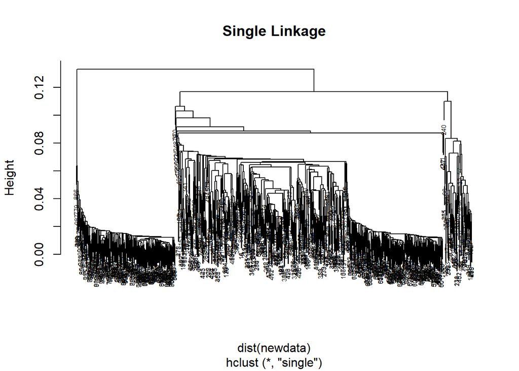

```r
# apply hierarchical clustering with both single linkage and complete linkage
single <- hclust(dist(newdata), method = "single")
plot(single, main = "Single Linkage", cex = 0.5)
```

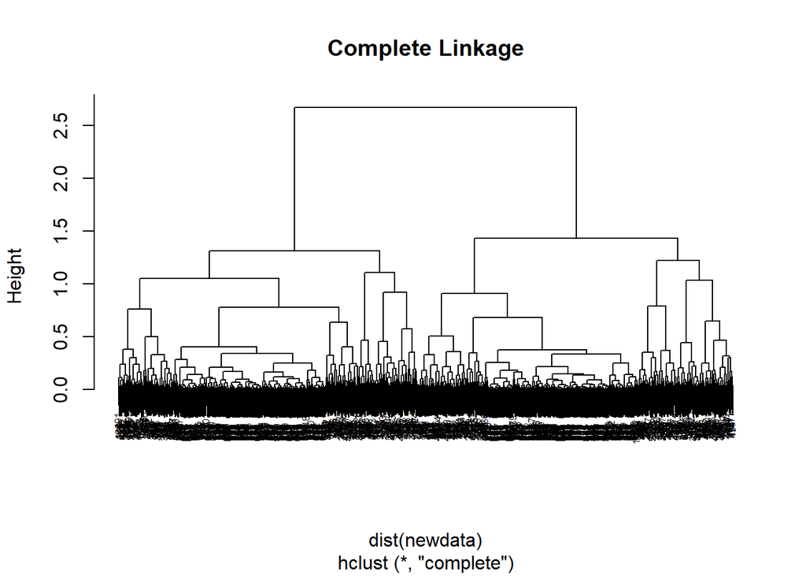

```r
complete <- hclust(dist(newdata), method = "complete")
plot(complete, main = "Complete Linkage", cex = 0.5)
```

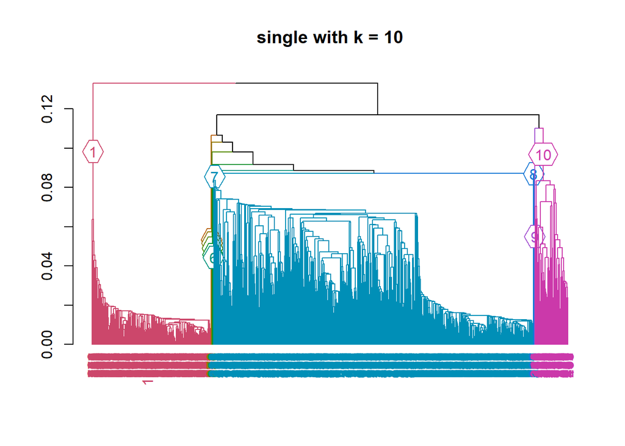

```r
# cut the trees at k = 10 and k = 20
group1 <- data.frame(cutree(single, k = 10))
group2 <- data.frame(cutree(single, k = 20))
group3 <- data.frame(cutree(complete, k = 10))
group4 <- data.frame(cutree(complete, k = 20))
colnames(group1) <- "cluster label"
colnames(group2) <- "cluster label"
colnames(group3) <- "cluster label"
colnames(group4) <- "cluster label"
group1$ID <- seq.int(nrow(group1))
group2$ID <- seq.int(nrow(group2))
group3$ID <- seq.int(nrow(group3))
group4$ID <- seq.int(nrow(group4))
# make some plots to show the cuts
library(dendextend)
dend <- as.dendrogram(single)
dend <- color_branches(dend, k = 10, groupLabels = TRUE)
dend <- color_labels(dend, k = 10)
plot(dend, main = "single with k = 10")
```

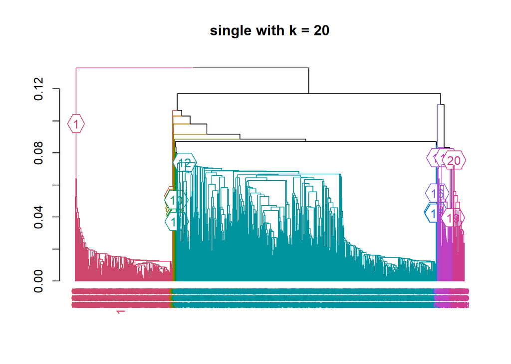

```r
dend_1 <- as.dendrogram(single)
dend_1 <- color_branches(dend_1, k = 20, groupLabels = TRUE)
dend_1 <- color_labels(dend_1, k = 20)
plot(dend_1, main = "single with k = 20")
```

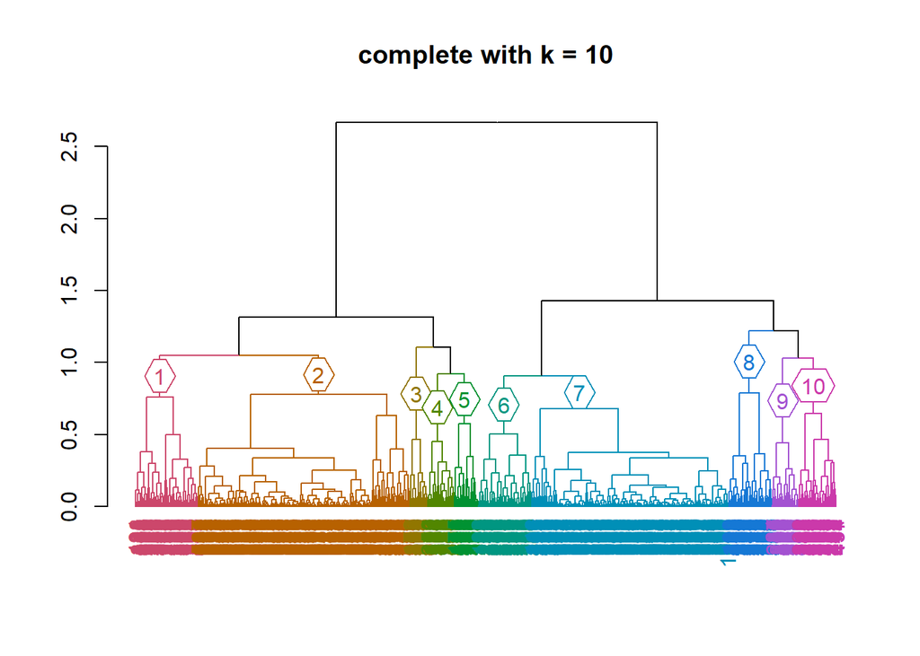

```r
dend_2 <- as.dendrogram(complete)
dend_2 <- color_branches(dend_2, k = 10, groupLabels = TRUE)
dend_2 <- color_labels(dend_2, k = 10)
plot(dend_2, main = "complete with k = 10")
```

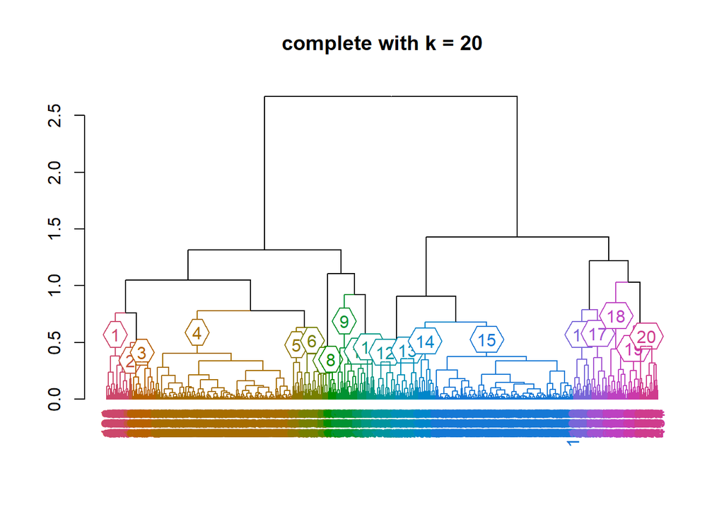

```r
dend_3 <- as.dendrogram(complete)
dend_3 <- color_branches(dend_3, k = 20, groupLabels = TRUE)
dend_3 <- color_labels(dend_3, k = 20)
plot(dend_3, main = "complete with k = 20")
```

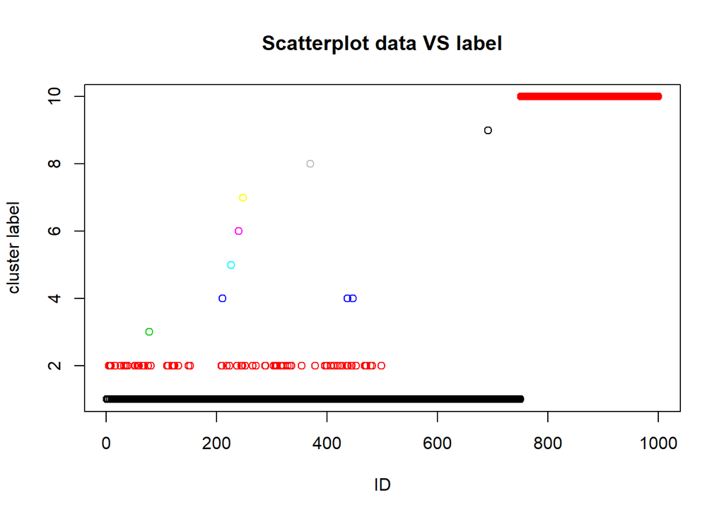

```r
# evaluate the clustering results with the selected approach
plot(group1$ID, group1$`cluster label`, xlab = "ID", ylab = "cluster label", main = "Scatterplot data VS label", col = factor(group1$`cluster label`))
```

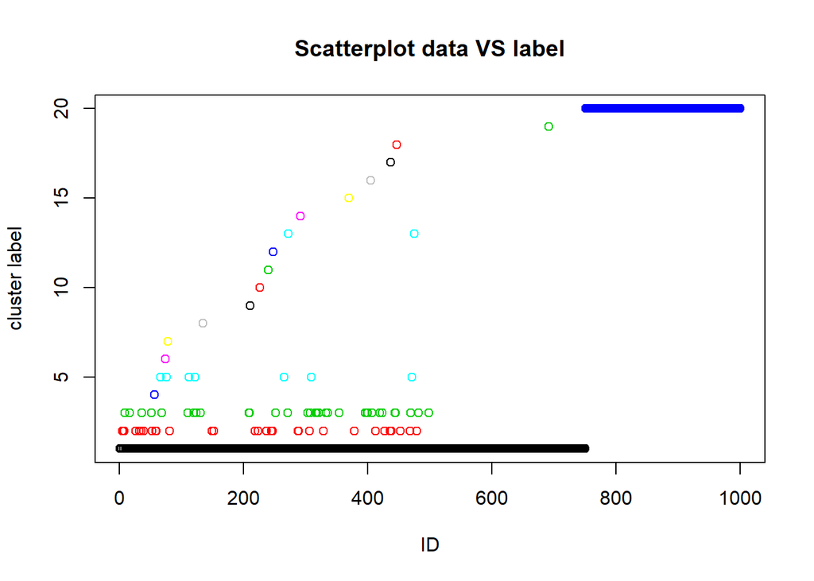

```r
plot(group2$ID, group2$`cluster label`, xlab = "ID", ylab = "cluster label", main = "Scatterplot data VS label", col = factor(group2$`cluster label`))
```

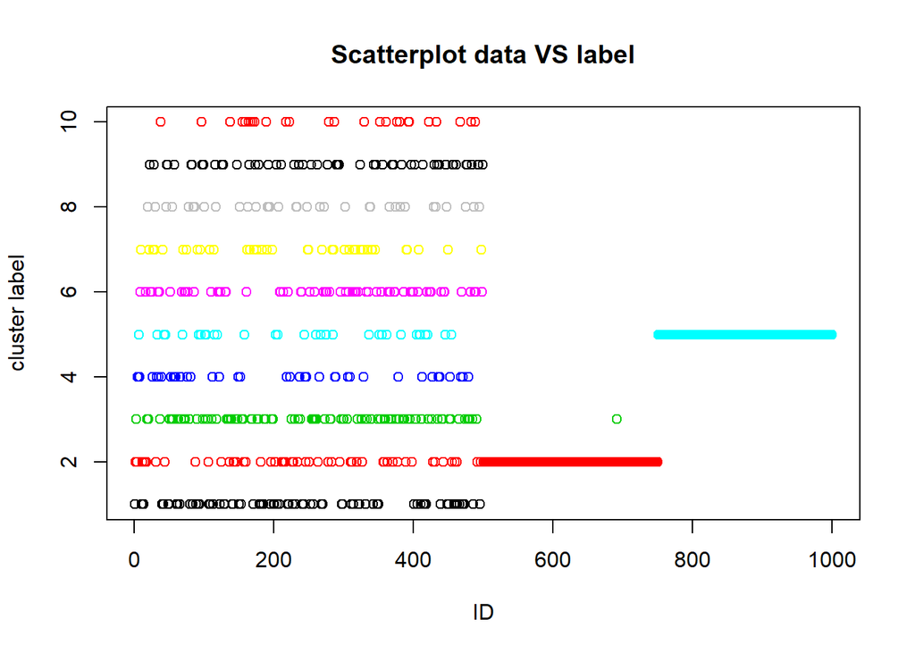

```r
plot(group3$ID, group3$`cluster label`, xlab = "ID", ylab = "cluster label", main = "Scatterplot data VS label", col = factor(group3$`cluster label`))
```

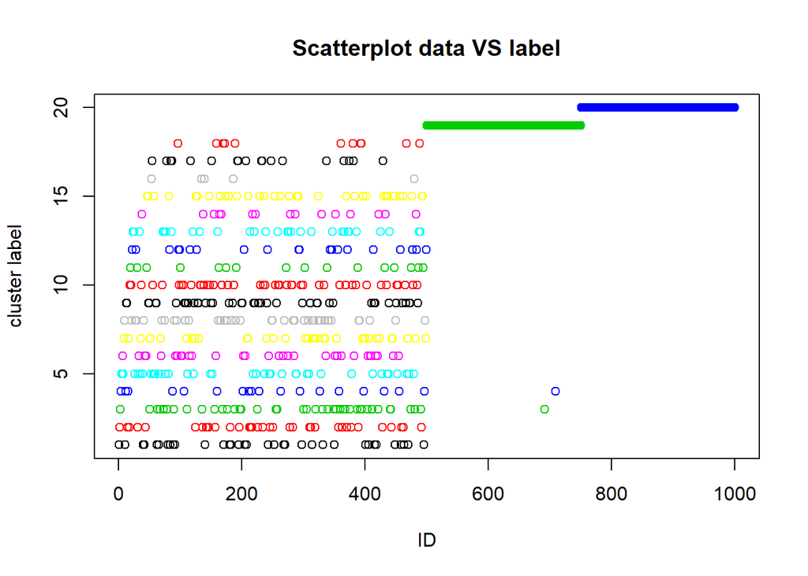

```r
plot(group4$ID, group4$`cluster label`, xlab = "ID", ylab = "cluster label", main = "Scatterplot data VS label", col = factor(group4$`cluster label`))
```

# b

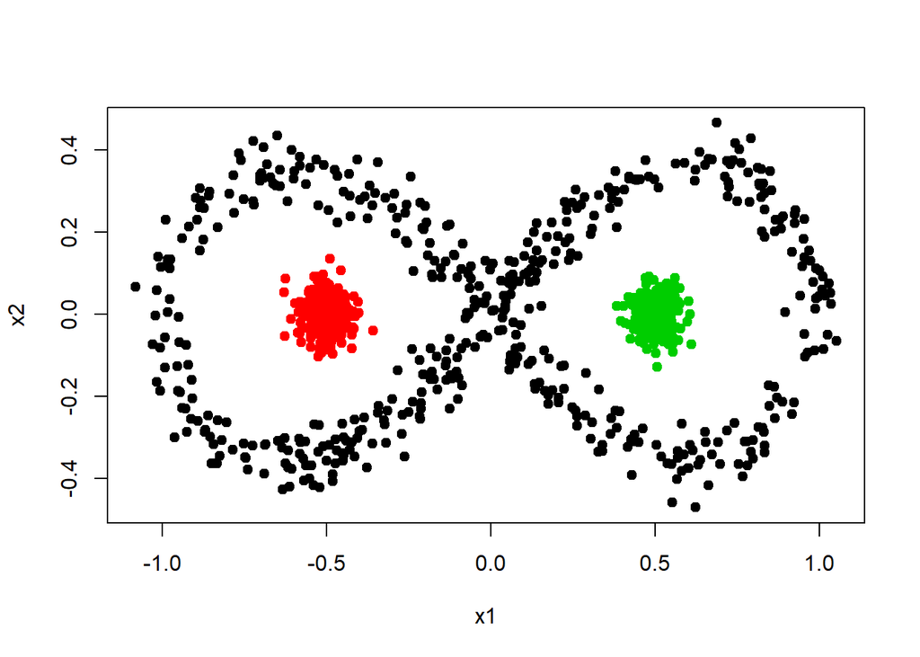

```r
# generate new data set and do data cleaning
set.seed(2019)
mydata <- make.eight(1000, spread = 0.04, makeplot = T)
```

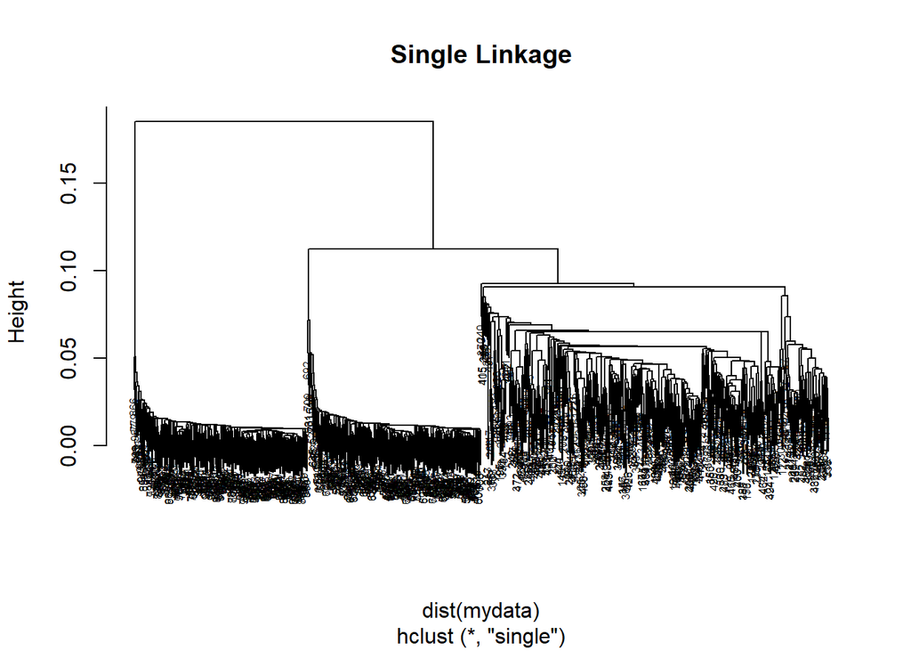

```r
mydata$label <- NULL
# apply hierarchical clustering with single linkage
single_1 <- hclust(dist(mydata), method = "single")
plot(single_1, main = "Single Linkage", cex = 0.5)
```

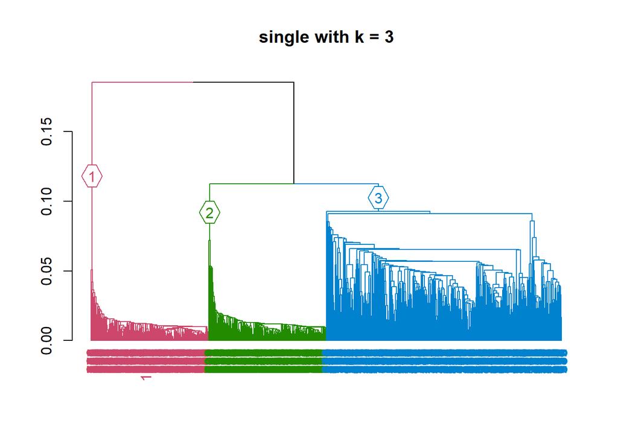

```r
# cut the tree at k = 3
group5 <- data.frame(cutree(single_1, k = 3))
colnames(group5) <- "cluster label"
group5$ID <- seq.int(nrow(group5))
# make a plot to show the cut
library(dendextend)
dend_4 <- as.dendrogram(single_1)
dend_4 <- color_branches(dend_4, k = 3, groupLabels = TRUE)
dend_4 <- color_labels(dend_4, k = 3)
plot(dend_4, main = "single with k = 3")
```

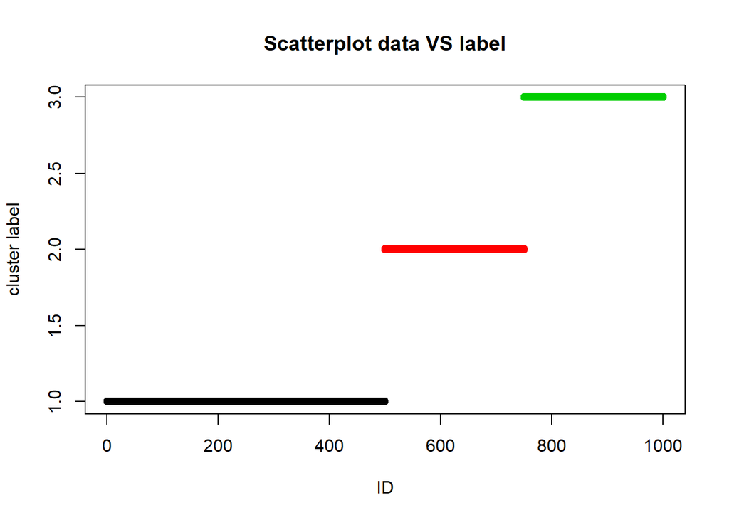

```r
# evaluate the clustering result with the selected approach
plot(group5$ID, group5$`cluster label`, xlab = "ID", ylab = "cluster label", main = "Scatterplot data VS label", col = factor(group5$`cluster label`))
```

I tried many different values of spread. Based on the graphs generated above, we can see that spread = 0.04 is already good to separate all data points into three clusters well. If you pick a value less than 0.04 but not negative, it might also fulfill the requirement of this problem. But 0.04 seems already sufficient here.